# Peer Assessment 1

assignment by Jaeyoon

### Loading and preprocessing the data

Codes below load data, and process it into a format suitable for analysis.

```r
data<-read.table("activity.csv",header=TRUE,sep=",")
library(date) # execute code [install.packages("date")] if you haven't installed packages "date"
data$date<-as.Date(data$date) # transform data's class into 'date'
```

### Q1. What is mean total number of steps taken per day(missing values ignored)

- Codes below make subset for analysis.

```r
subset_day<-aggregate(data$steps,by=list(data$date),FUN=sum) # makes subset which counts steps by(per) date
head(subset_day) # shows head of subset
```

```
##      Group.1     x
## 1 2012-10-01    NA
## 2 2012-10-02   126
## 3 2012-10-03 11352
## 4 2012-10-04 12116
## 5 2012-10-05 13294
## 6 2012-10-06 15420
```

- Histogram of the total number of steps taken each day

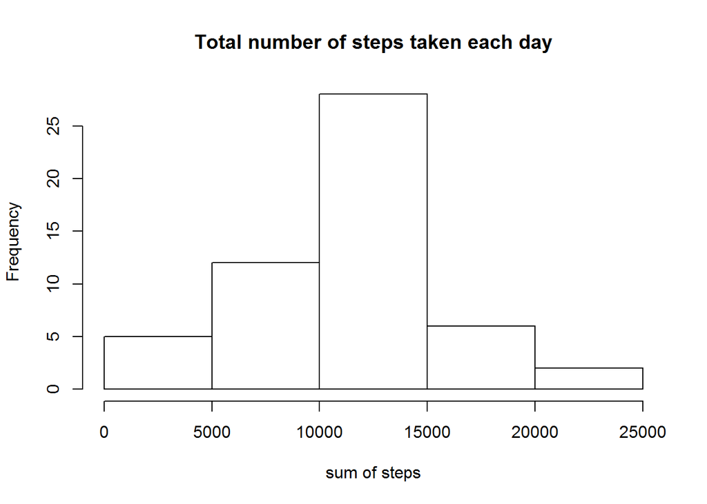

```r
hist(subset_day[[2]],main="Total number of steps taken each day",xlab="sum of steps") # makes histogram
```

- Mean and median total number of steps taken per day

```r
mean<-mean(subset_day[[2]],na.rm=TRUE)
median<-median(subset_day[[2]],na.rm=TRUE)
```

mean : **1.0766 × 10<sup>4</sup>** / median : **10765**

### Q2. What is the average daily activity pattern?

- Codes below make subset for analysis.

```r
subset_itv<-aggregate(data$steps,by=list(data$interval),FUN=mean,na.rm=TRUE) # makes subset which average(mean) steps by(per) intervals
head(subset_itv) # shows head of subset
```

```
##   Group.1       x
## 1       0 1.71698
## 2       5 0.33962
## 3      10 0.13208
## 4      15 0.15094
## 5      20 0.07547
## 6      25 2.09434
```

- Plot of the average daily activity pattern

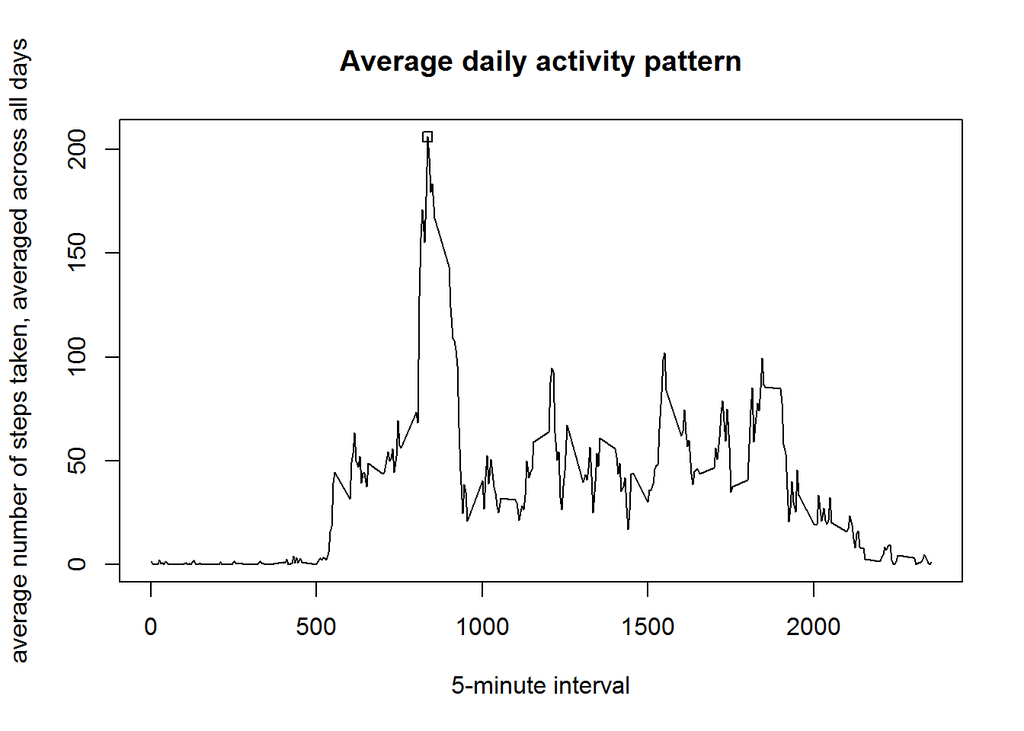

```r
plot(subset_itv,main="Average daily activity pattern",type="l",xlab="5-minute interval",ylab="average number of steps taken, averaged across all days") # makes plot
max_row<-subset_itv[which.max(subset_itv[[2]]),1] # finds interval contains maximum number of steps
points(max_row,max(subset_itv[[2]]),pch=22) # indicate maximum value
```

The interval which contains maximum number of steps is **835**